# Practical Machine Learning course project

Greg Michalopoulos

April 14, 2016

## Executive Summary

Using a [random forest](https://en.wikipedia.org/wiki/Random_forest) to classify sensor data into classes of exercise, it can be determined, with very high accuracy, whether or not an exercise was done correctly. Additionally, if the exercise is done incorrectly, it can be determined to be one of four common mistakes made by people trying to exercise.

## The data set

The data set is the [Weight Lifting Exercises Dataset](http://groupware.les.inf.puc-rio.br/har#weight_lifting_exercises) that captures data from various sensors. The participants were asked to perform exercises in a specific way to capture data for proper and improper technique. The exact technique is captured as `classe` with values A through E.

In order to prepare the data for model training, only columns that contribute to the model (readings from the sensors) are kept. Also only columns that are not blank in the test data set are kept in the training set to train the model. If the column is unavailable in the test data set, there is no point building a model based on that data.

```r
cleanData <- function(inputData){
  outputData <- lapply(inputData[,8:159], as.numeric)
  outputData$classe <- inputData$classe
  outputData <- data.frame(outputData)
}

training <- cleanData(read.csv(textConnection(getURL("https://d396qusza40orc.cloudfront.net/predmachlearn/pml-training.csv"))))
testing <- cleanData(read.csv(textConnection(getURL("https://d396qusza40orc.cloudfront.net/predmachlearn/pml-testing.csv"))))

# Identify and remove columns that are all NA
isNa <- lapply(testing, is.na)
isNa <- lapply(isNa, sum)
keepColumns <- isNa == 0

rTraining <- training[, keepColumns]
rTesting <- testing[, keepColumns]
```

## Models

Four model types are trained and tested for their in-sample accuracy.

- Random Forest (rf)
- Classification A Regression Tree (rpart)
- Stochastic Gradient Boosting (gbm)
- Linear Discriminant Analysis (lda)

### Cross-Validation

For each model, the resampling method used was bootstrapping with 25 repetitions.

```r
# Model training took a long time, like 2+ hrs so after one time, I cached the model objects to disk
# .PML2 file.  Model training is in Models.Rmd.
load(file = "C:/Users/gmich/Documents/.PML2")
#rffit <- train(classe ~., data = rTraining, method = "rf")
rfpred <- predict(rffit, newdata = rTraining)
#rpartfit <- train(classe ~., data = rTraining, method = "rpart")
rpartpred <- predict(rpartfit, newdata = rTraining)
#gbmfit <- train(classe ~., data = rTraining, method = "gbm", verbose = FALSE)
gbmpred <- predict(gbmfit, newdata = rTraining)
#ldafit <- train(classe ~., data = rTraining, method = "lda")
ldapred <- predict(ldafit, newdata = rTraining)

rfacc <- sum(rfpred == rTraining$classe)/length(rfpred)
rpartacc <- sum(rpartpred == rTraining$classe)/length(rpartpred)
gbmacc <- sum(gbmpred == rTraining$classe)/length(gbmpred)
ldaacc <- sum(ldapred == rTraining$classe)/length(ldapred)
```

### Model Accuracy

Just looking at model accuracy, the following in-sample (training) results:

| Model | Accuracy |
| --- | --- |
| Random Forest (rf) | 100% |
| Classification A Regression Tree (rpart) | 49.6% |
| Stochastic Gradient Boosting (gbm) | 97.3% |
| Linear Discriminant Analysis (lda) | 70.5% |

Seeing that random forest provided the highest accuracy, let’s take a look at its Kappa value and other information from the `confusionMatrix` method:

```
## Confusion Matrix and Statistics
##
##           Reference
## Prediction    A    B    C    D    E
##          A 5580    0    0    0    0
##          B    0 3797    0    0    0
##          C    0    0 3422    0    0
##          D    0    0    0 3216    0
##          E    0    0    0    0 3607
##
## Overall Statistics
##
##                Accuracy : 1
##                  95% CI : (0.9998, 1)
##     No Information Rate : 0.2844
##     P-Value [Acc > NIR] : < 2.2e-16
##
##                   Kappa : 1
##  Mcnemar's Test P-Value : NA
##
## Statistics by Class:
##
##                      Class: A Class: B Class: C Class: D Class: E
## Sensitivity            1.0000   1.0000   1.0000   1.0000   1.0000
## Specificity            1.0000   1.0000   1.0000   1.0000   1.0000
## Pos Pred Value         1.0000   1.0000   1.0000   1.0000   1.0000
## Neg Pred Value         1.0000   1.0000   1.0000   1.0000   1.0000
## Prevalence             0.2844   0.1935   0.1744   0.1639   0.1838
## Detection Rate         0.2844   0.1935   0.1744   0.1639   0.1838
## Detection Prevalence   0.2844   0.1935   0.1744   0.1639   0.1838
## Balanced Accuracy      1.0000   1.0000   1.0000   1.0000   1.0000
```

The Kappa value is 1 and other metrics look good too, so this is the model chosen to run on the testing data for the prediction. Here is a plot of the model results, Accuracy vs. # Randomly Selected of Predictors

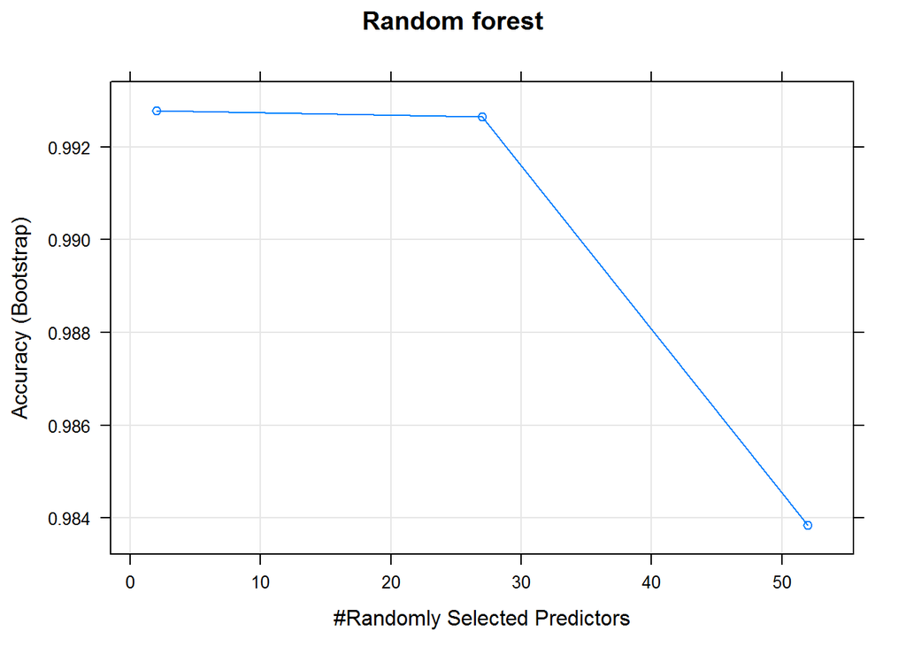

The random forest actually had the highest accuracy with only 2 randomly selected predictors. This is what was used to predict the results on the test data.

## Prediction

The testing data is run through the random forest model to produce the following results:

```r
rfoospred <- predict(rffit, newdata = rTesting)
rfoospred
```

```
##  [1] B A B A A E D B A A B C B A E E A B B B
## Levels: A B C D E
```

These results were verified on the course final quiz.